# Choosing the best model for House Price Prediction

## Fitting of Models

After the data has been split, the next step involves training our models using the trainData dataset.Then we will fit three models viz. Linear Regression models , Random Forest Model and XGBoost (Extreme Gradient Boosting) model.

- Linear Regression Model:

```
## [1] "bathrooms"       "airconditioning" "hotwaterheating" "prefarea"
## [5] "stories"
```

**Interpretation:**

we have first fitted a linear model using all variables.Then we have extracted the top 5 most important features based on the absolute values of the model’s coefficients.Then fitted a new Linear Regression model using only the top 5 features.Predict on the test dataset and calculate R-squared and RMSE values.

- Random Forest Model:

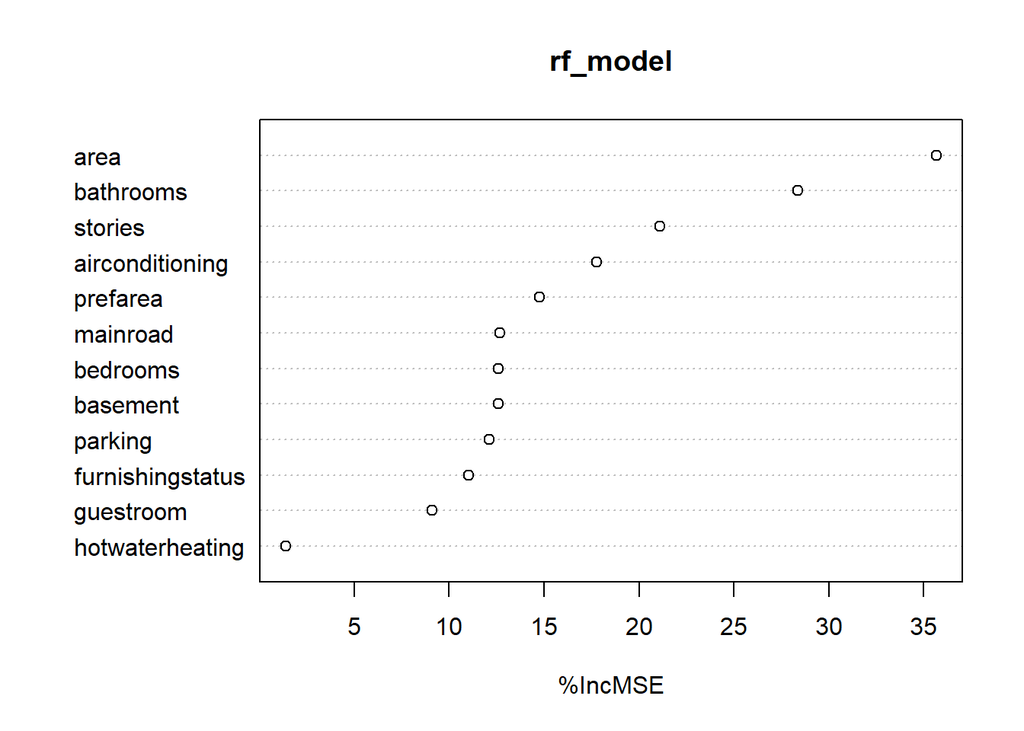

```
##                    %IncMSE IncNodePurity
## area             35.663642  4.779748e+14
## bathrooms        28.371280  2.440324e+14
## stories          21.090991  1.159343e+14
## airconditioning  17.754786  1.437173e+14
## prefarea         14.752713  6.459508e+13
## mainroad         12.677850  2.566559e+13
## bedrooms         12.584628  7.651841e+13
## basement         12.576039  4.585950e+13
## parking          12.091317  1.360840e+14
## furnishingstatus 11.038688  7.244017e+13
## guestroom         9.110823  2.904699e+13
## hotwaterheating   1.401100  2.321448e+13
```

```
## [1] "area"            "bathrooms"       "stories"         "airconditioning"
## [5] "prefarea"
```

**Interpretation:**

- XGBoost Model:

```
##              Feature       Gain       Cover  Frequency
##  1:             area 0.46752389 0.650338081 0.51792057
##  2:        bathrooms 0.16434935 0.041241558 0.04875686
##  3:  airconditioning 0.09904115 0.021205283 0.02453988
##  4:          stories 0.06299644 0.049521716 0.06845334
##  5:          parking 0.04556647 0.056931914 0.07394253
##  6: furnishingstatus 0.04452631 0.027559101 0.06199548
##  7:         prefarea 0.02737959 0.023535534 0.02680013
##  8:         bedrooms 0.02291464 0.060454477 0.08104617
##  9:         basement 0.02221213 0.014979630 0.03874717
## 10:        guestroom 0.01649405 0.016447688 0.02712302
## 11:  hotwaterheating 0.01381720 0.028898995 0.01485308
## 12:         mainroad 0.01317877 0.008886024 0.01582176
```

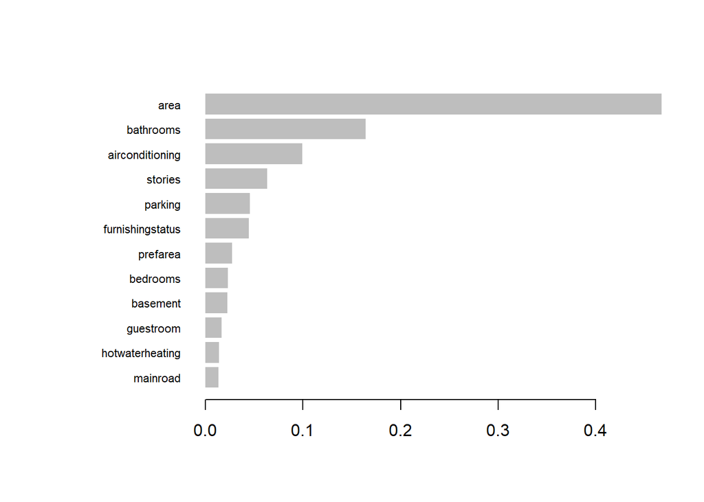

```
## [1] "area"            "bathrooms"       "airconditioning" "stories"
## [5] "parking"
```

**Interpretation:**

RMSE and R-squared Values for Different Models

| Model | RMSE | R_squared |
| --- | --- | --- |
| Linear Regression | 1189149 | 0.5378247 |
| Random Forest | 1123452 | 0.5856378 |
| XGBoost | 1344775 | 0.4807177 |

## Conclusion

Among the models evaluated, the Random Forest model demonstrates the best balance of explanatory power and prediction accuracy, as indicated by its highest R-squared value and lowest RMSE. The Linear Regression model offers a moderate fit, while the XGBoost model, despite its advanced nature, performs less effectively in this case compared to the other models.

## Appendix: All code for this report

click here

```r
library(tidyverse)
library(caret)
library(dplyr)
library(tidyr)
library(randomForest)
library(xgboost)
library(gridExtra)
library(corrplot)
library(ggplot2)
library(ggcorrplot)
library(randomForest)
library(scales)
library(Metrics)
library(Matrix)
library(kableExtra)
data <- read.csv("C:/Users/DELL/OneDrive/Desktop/project/projects/Housing.csv")
head(data)
colSums(is.na(data))
sum(duplicated(data))
sum(is.na(data))
summary(data)
data$mainroad=as.factor(data$mainroad)
data$guestroom=as.factor(data$guestroom)
data$basement=as.factor(data$basement)
data$hotwaterheating=as.factor(data$hotwaterheating)
data$airconditioning=as.factor(data$airconditioning)
data$prefarea=as.factor(data$prefarea)
data$furnishingstatus=as.factor(data$furnishingstatus)
str(data)
par(mfrow=c(1, 2), mar=c(4, 4, 2, 1))
hist(data$area, probability=TRUE, col="skyblue", main="Histogram of area", xlab="Area", breaks=20)
lines(density(data$area), col="red")
boxplot(data$area, main="Boxplot of area", col="skyblue", horizontal=TRUE)
par(mfrow=c(1, 2), mar=c(4, 4, 2, 1))
hist(data$bedrooms, probability=TRUE, col="skyblue", main="Histogram of bedrooms", xlab="Bedrooms", breaks=20)
lines(density(data$bedrooms), col="red")
boxplot(data$bedrooms, main="Boxplot of bedrooms", col="skyblue", horizontal=TRUE)
par(mfrow=c(1, 2), mar=c(4, 4, 2, 1))
hist(data$bathrooms, probability=TRUE, col="skyblue", main="Histogram of bathrooms", xlab="Bathrooms", breaks=20)
lines(density(data$bedrooms), col="red")
boxplot(data$bathrooms, main="Boxplot of bathrooms", col="skyblue", horizontal=TRUE)
par(mfrow=c(1, 2), mar=c(4, 4, 2, 1))
hist(data$stories, probability=TRUE, col="skyblue", main="Histogram of stories", xlab="Stories", breaks=20)
lines(density(data$stories), col="red")
boxplot(data$stories, main="Boxplot of stories", col="skyblue", horizontal=TRUE)
par(mfrow=c(1, 2), mar=c(4, 4, 2, 1))
hist(data$parking, probability=TRUE, col="skyblue", main="Histogram of parking", xlab="Parking", breaks=20)
lines(density(data$parking), col="red")
boxplot(data$parking, main="Boxplot of parking", col="skyblue", horizontal=TRUE)
count_mainroad <- table(data$mainroad)
count_mainroad_df <- as.data.frame(count_mainroad)

explode <- c(0, 0.09)

ggplot(count_mainroad_df, aes(x = "", y = Freq, fill = as.factor(Var1))) +
  geom_bar(width = 1, stat = "identity") +
  coord_polar(theta = "y") +
  scale_fill_manual(values = scales::brewer_pal(palette = "Blues")(length(unique(count_mainroad_df$Var1)))) +
  geom_text(aes(label = paste0(round(Freq/sum(Freq)*100), "%")),
            position = position_stack(vjust = 0.5)) +
  labs(title = "Count of Mainroad", fill = "Mainroad") +
  theme_void() +
  theme(legend.position = "right")
guestroom_count <- data %>%
  count(guestroom)
explode <- c(0, 0.09)
colors <- scale_fill_manual(values = c("#08306b", "#2171b5", "#4292c6", "#6baed6"))

pie <- ggplot(guestroom_count, aes(x = "", y = n, fill = factor(guestroom))) +
  geom_bar(width = 1, stat = "identity") +
  coord_polar("y", start = 0) +
  scale_fill_manual(values = c("#2171b5", "#6baed6")) +
  geom_text(aes(label = percent(n/sum(n))), position = position_stack(vjust = 0.5)) +
  labs(title = "Count of Guestroom", fill = "Guestroom") +
  theme_void() +
  theme(legend.position = "right")

print(pie)
count_basement <- table(data$basement)
count_basement_df <- as.data.frame(count_basement)

explode <- c(0, 0.09)

ggplot(count_basement_df, aes(x = "", y = Freq, fill = as.factor(Var1))) +
  geom_bar(width = 1, stat = "identity") +
  coord_polar(theta = "y") +
  scale_fill_manual(values = scales::brewer_pal(palette = "Blues")(length(unique(count_basement_df$Var1)))) +
  geom_text(aes(label = paste0(round(Freq/sum(Freq)*100), "%")),
            position = position_stack(vjust = 0.5)) +
  labs(title = "Count of Basement", fill = "Basement") +
  theme_void() +
  theme(legend.position = "right")
hotwaterheating_count <- data %>%
  count(hotwaterheating)

explode <- c(0, 0.09)
colors <- scale_fill_manual(values = c("#08306b", "#2171b5", "#4292c6", "#6baed6"))

pie <- ggplot(hotwaterheating_count, aes(x = "", y = n, fill = factor(hotwaterheating))) +
  geom_bar(width = 1, stat = "identity") +
  coord_polar("y", start = 0) +
  scale_fill_manual(values = c("#2171b5", "#6baed6")) +
  geom_text(aes(label = percent(n/sum(n))), position = position_stack(vjust = 0.5)) +
  labs(title = "Count of Hot Water Heating System", fill = "Hot Water Heating") +
  theme_void() +
  theme(legend.position = "right")

print(pie)
count_ac <- table(data$airconditioning)
count_ac_df <- as.data.frame(count_ac)

explode <- c(0, 0.09)

ggplot(count_ac_df, aes(x = "", y = Freq, fill = as.factor(Var1))) +
  geom_bar(width = 1, stat = "identity") +
  coord_polar(theta = "y") +
  scale_fill_manual(values = scales::brewer_pal(palette = "Blues")(length(unique(count_ac_df$Var1)))) +
  geom_text(aes(label = paste0(round(Freq/sum(Freq)*100), "%")),
            position = position_stack(vjust = 0.5)) +
  labs(title = "Count of aircondtioning", fill = "Airconditioning") +
  theme_void() +
  theme(legend.position = "right")

prefarea_count <- data %>%
  count(prefarea)

explode <- c(0, 0.09)
colors <- scale_fill_manual(values = c("#08306b", "#2171b5", "#4292c6", "#6baed6"))

pie <- ggplot(prefarea_count, aes(x = "", y = n, fill = factor(prefarea))) +
  geom_bar(width = 1, stat = "identity") +
  coord_polar("y", start = 0) +
  scale_fill_manual(values = c("#2171b5", "#6baed6")) +
  geom_text(aes(label = percent(n/sum(n))), position = position_stack(vjust = 0.5)) +
  labs(title = "Count of Preffered Area", fill = "Preffered Area") +
  theme_void() +
  theme(legend.position = "right")

print(pie)
count_furnishing <- table(data$furnishingstatus)
count_furnishing_df <- as.data.frame(count_furnishing)

explode <- c(0, 0.09)

ggplot(count_furnishing_df, aes(x = "", y = Freq, fill = as.factor(Var1))) +
  geom_bar(width = 1, stat = "identity") +
  coord_polar(theta = "y") +
  scale_fill_manual(values = scales::brewer_pal(palette = "Blues")(length(unique(count_furnishing_df$Var1)))) +
  geom_text(aes(label = paste0(round(Freq/sum(Freq)*100), "%")),
            position = position_stack(vjust = 0.5)) +
  labs(title = "Count of Furnishing Status", fill = "Furnishing Status") +
  theme_void() +
  theme(legend.position = "right")
data$mainroad=as.numeric(data$mainroad)
data$guestroom=as.numeric(data$guestroom)
data$basement=as.numeric(data$basement)
data$hotwaterheating=as.numeric(data$hotwaterheating)
data$airconditioning=as.numeric(data$airconditioning)
data$prefarea=as.numeric(data$prefarea)
data$furnishingstatus=as.numeric(data$furnishingstatus)
data %>%
  head(400) %>%
  select(c("price", "area", "bedrooms", "bathrooms", "stories", "mainroad", "guestroom", "basement","hotwaterheating","airconditioning","parking","prefarea","furnishingstatus")) %>%
  pivot_longer(cols = -price, names_to = 'param') %>%
  ggplot(aes(x = value, y = price, colour = param)) +
  geom_point(size = 0.2) +
  geom_smooth(formula = y ~ x, method = "loess") +
  theme(axis.text.x = element_text(hjust = 1),
        axis.title.x = element_blank(),
        axis.title.y = element_blank(),
        legend.position = "none") +
  facet_wrap(~param, scales = 'free_x')  +
  labs(
    title = 'Trends in each parameter',
    x = 'Parameters',
    y = 'Values'
  )
```

```r
data$mainroad=as.numeric(data$mainroad)
data$guestroom=as.numeric(data$guestroom)
data$basement=as.numeric(data$basement)
data$hotwaterheating=as.numeric(data$hotwaterheating)
data$airconditioning=as.numeric(data$airconditioning)
data$prefarea=as.numeric(data$prefarea)
data$furnishingstatus=as.numeric(data$furnishingstatus)

cor_matrix <- cor(data)

corr.plot <- ggcorrplot(cor_matrix, type = "lower", lab = TRUE, p.mat = NULL,
                        lab_size = 2, pch = 1, pch.col = "black", pch.cex =1, tl.cex = 6)
corr.plot

set.seed(42)
trainIndex <- createDataPartition(data$price, p = 0.8, list = FALSE)
trainData <- data[trainIndex, ]
testData <- data[-trainIndex, ]
#linear regression model
# Fit the Linear Regression model on the training data
lm_model <- lm(price ~ ., data = trainData)
# Get the absolute values of coefficients
importance_values <- abs(coef(lm_model)[-1])  # Exclude the intercept

# Sort the coefficients by importance
sorted_importance <- sort(importance_values, decreasing = TRUE)

# Select the top 5 important features
top_5_features <- names(sorted_importance)[1:5]

# Print the top 5 important features
print(top_5_features)
# Create a formula with the top 5 features
formula <- as.formula(paste("price ~", paste(top_5_features, collapse = " + ")))

# Fit a new Linear Regression model using the top 5 features
lm_model_top5 <- lm(formula, data = trainData)
# Predict on the test dataset
predictions <- predict(lm_model_top5, newdata = testData)
# Calculate R-squared
r_squared_linear <- caret::R2(predictions, testData$price)

# Calculate RMSE
rmse_value_linear <- caret::RMSE(predictions, testData$price)
#random forest model
rf_model <- randomForest(price ~ ., data = trainData, importance = TRUE)
varImpPlot(rf_model,type = 1)
# Get feature importance
importance_values <- importance(rf_model)
# Sort the importance values by the %IncMSE column in decreasing order
sorted_importance <- importance_values[order(importance_values[, "%IncMSE"], decreasing = TRUE), ]

# Print the sorted importance values
print(sorted_importance)

# Select the top 5 important features
top_5_features <- rownames(sorted_importance)[1:5]

# Print the top 5 important features
print(top_5_features)# Create a formula with the top 5 features
formula <- as.formula(paste("price ~", paste(top_5_features, collapse = " + ")))

# Fit a new Random Forest model using the top 5 features
rf_model_top5 <- randomForest(formula, data = trainData)
# Predict on the test dataset
predictions <- predict(rf_model_top5, newdata = testData)
# Calculate R-squared
r_squared_rf <- caret::R2(predictions, testData$price)

# Calculate RMSE
rmse_value_rf <- caret::RMSE(predictions, testData$price)
# Convert the dataset to a matrix (excluding the target variable)
train_matrix <- sparse.model.matrix(price ~ . - 1, data = trainData)
test_matrix <- sparse.model.matrix(price ~ . - 1, data = testData)

# Extract the target variable
train_labels <- trainData$price
test_labels <- testData$price

# Prepare DMatrix objects for XGBoost
dtrain <- xgb.DMatrix(data = train_matrix, label = train_labels)
dtest <- xgb.DMatrix(data = test_matrix, label = test_labels)
# Set parameters for XGBoost
params <- list(
  objective = "reg:squarederror",
  eval_metric = "rmse",
  booster = "gbtree"
)

# Train the XGBoost model
xgb_model <- xgb.train(
  params = params,
  data = dtrain,
  nrounds = 100,
  watchlist = list(train = dtrain),
  verbose = 0
)
# Get feature importance
importance_matrix <- xgb.importance(model = xgb_model)
xgb_importance <- xgb.importance(model = xgb_model)
print(xgb_importance)
xgb.plot.importance(xgb_importance)

# Select the top 5 important features
top_5_features <- importance_matrix$Feature[1:5]

# Print the top 5 important features
print(top_5_features)
# Prepare DMatrix with the top 5 features
train_matrix_top5 <- sparse.model.matrix(as.formula(paste("price ~", paste(top_5_features, collapse = " + "))), data = trainData)
test_matrix_top5 <- sparse.model.matrix(as.formula(paste("price ~", paste(top_5_features, collapse = " + "))), data = testData)

dtrain_top5 <- xgb.DMatrix(data = train_matrix_top5, label = train_labels)
dtest_top5 <- xgb.DMatrix(data = test_matrix_top5, label = test_labels)

# Train the XGBoost model using the top 5 features
xgb_model_top5 <- xgb.train(
  params = params,
  data = dtrain_top5,
  nrounds = 100,
  watchlist = list(train = dtrain_top5),
  verbose = 0
)
# Predict on the test dataset
predictions <- predict(xgb_model_top5, newdata = dtest_top5)
# Calculate R-squared
r_squared_xgb <- caret::R2(predictions, test_labels)

# Calculate RMSE
rmse_value_xgb <- caret::RMSE(predictions, test_labels)
# Create the evaluation table
evaluation_table <- data.frame(
  Model = c("Linear Regression", "Random Forest", "XGBoost"),
  RMSE = c(rmse_value_linear, rmse_value_rf, rmse_value_xgb),
  R_squared = c(r_squared_linear, r_squared_rf, r_squared_xgb)
)

# Print the table with borders and styling
kable(evaluation_table, caption = "RMSE and R-squared Values for Different Models",
      format = "html") %>%
  kable_styling(
    bootstrap_options = c("striped", "hover", "condensed", "responsive"),
    position = "center",
    full_width = FALSE,
    font_size = 12
  )
library(tidyverse)
library(caret)
library(dplyr)
library(tidyr)
library(randomForest)
library(xgboost)
library(gridExtra)
library(corrplot)
library(ggplot2)
library(ggcorrplot)
library(randomForest)
library(scales)
library(Metrics)
library(Matrix)
library(kableExtra)
data <- read.csv("C:/Users/DELL/OneDrive/Desktop/project/projects/Housing.csv")
head(data)
colSums(is.na(data))
sum(duplicated(data))
sum(is.na(data))
summary(data)
data$mainroad=as.factor(data$mainroad)
data$guestroom=as.factor(data$guestroom)
data$basement=as.factor(data$basement)
data$hotwaterheating=as.factor(data$hotwaterheating)
data$airconditioning=as.factor(data$airconditioning)
data$prefarea=as.factor(data$prefarea)
data$furnishingstatus=as.factor(data$furnishingstatus)
str(data)
par(mfrow=c(1, 2), mar=c(4, 4, 2, 1))
hist(data$area, probability=TRUE, col="skyblue", main="Histogram of area", xlab="Area", breaks=20)
lines(density(data$area), col="red")
boxplot(data$area, main="Boxplot of area", col="skyblue", horizontal=TRUE)
par(mfrow=c(1, 2), mar=c(4, 4, 2, 1))
hist(data$bedrooms, probability=TRUE, col="skyblue", main="Histogram of bedrooms", xlab="Bedrooms", breaks=20)
lines(density(data$bedrooms), col="red")
boxplot(data$bedrooms, main="Boxplot of bedrooms", col="skyblue", horizontal=TRUE)
par(mfrow=c(1, 2), mar=c(4, 4, 2, 1))
hist(data$bathrooms, probability=TRUE, col="skyblue", main="Histogram of bathrooms", xlab="Bathrooms", breaks=20)
lines(density(data$bedrooms), col="red")
boxplot(data$bathrooms, main="Boxplot of bathrooms", col="skyblue", horizontal=TRUE)
par(mfrow=c(1, 2), mar=c(4, 4, 2, 1))
hist(data$stories, probability=TRUE, col="skyblue", main="Histogram of stories", xlab="Stories", breaks=20)
lines(density(data$stories), col="red")
boxplot(data$stories, main="Boxplot of stories", col="skyblue", horizontal=TRUE)
par(mfrow=c(1, 2), mar=c(4, 4, 2, 1))
hist(data$parking, probability=TRUE, col="skyblue", main="Histogram of parking", xlab="Parking", breaks=20)
lines(density(data$parking), col="red")
boxplot(data$parking, main="Boxplot of parking", col="skyblue", horizontal=TRUE)
count_mainroad <- table(data$mainroad)
count_mainroad_df <- as.data.frame(count_mainroad)
```